# Datathon 2026 — The Gridbreakers

|  | dtype | non_null | nulls | null_% | nunique |
| --- | --- | --- | --- | --- | --- |
| review_id | str | 113551 | 0 | 0.00 | 113551 |
| order_id | int64 | 113551 | 0 | 0.00 | 111369 |
| product_id | int64 | 113551 | 0 | 0.00 | 1412 |
| customer_id | int64 | 113551 | 0 | 0.00 | 48676 |
| review_date | datetime64[us] | 113551 | 0 | 0.00 | 3825 |
| rating | int64 | 113551 | 0 | 0.00 | 5 |
| review_title | str | 113551 | 0 | 0.00 | 18 |

`sales` — shape (3833, 3)

|  | Date | Revenue | COGS |
| --- | --- | --- | --- |
| 0 | 2012-07-04 | 5,123,547.94 | 3,982,991.19 |
| 1 | 2012-07-05 | 2,751,773.45 | 2,150,580.23 |
| 2 | 2012-07-06 | 3,054,029.42 | 2,517,632.84 |

|  | dtype | non_null | nulls | null_% | nunique |
| --- | --- | --- | --- | --- | --- |
| Date | datetime64[us] | 3833 | 0 | 0.00 | 3833 |
| Revenue | float64 | 3833 | 0 | 0.00 | 3833 |
| COGS | float64 | 3833 | 0 | 0.00 | 3833 |

`inventory` — shape (60247, 17)

|  | snapshot_date | product_id | stock_on_hand | units_received | units_sold | stockout_days | days_of_supply | fill_rate | stockout_flag | overstock_flag | reorder_flag | sell_through_rate | product_name | category | segment | year | month |
| --- | --- | --- | --- | --- | --- | --- | --- | --- | --- | --- | --- | --- | --- | --- | --- | --- | --- |
| 0 | 2022-10-31 | 1 | 3 | 1 | 1 | 2 | 90.00 | 0.93 | 1 | 0 | 0 | 0.25 | DragonWear MA-01 | Casual | All-weather | 2022 | 10 |
| 1 | 2022-11-30 | 1 | 3 | 1 | 1 | 1 | 90.00 | 0.97 | 1 | 0 | 0 | 0.25 | DragonWear MA-01 | Casual | All-weather | 2022 | 11 |
| 2 | 2022-12-31 | 1 | 3 | 1 | 1 | 1 | 90.00 | 0.97 | 1 | 0 | 0 | 0.25 | DragonWear MA-01 | Casual | All-weather | 2022 | 12 |

|  | dtype | non_null | nulls | null_% | nunique |
| --- | --- | --- | --- | --- | --- |
| snapshot_date | datetime64[us] | 60247 | 0 | 0.00 | 126 |
| product_id | int64 | 60247 | 0 | 0.00 | 1624 |
| stock_on_hand | int64 | 60247 | 0 | 0.00 | 1895 |
| units_received | int64 | 60247 | 0 | 0.00 | 360 |
| units_sold | int64 | 60247 | 0 | 0.00 | 303 |
| stockout_days | int64 | 60247 | 0 | 0.00 | 29 |
| days_of_supply | float64 | 60247 | 0 | 0.00 | 9289 |
| fill_rate | float64 | 60247 | 0 | 0.00 | 29 |
| stockout_flag | int64 | 60247 | 0 | 0.00 | 2 |
| overstock_flag | int64 | 60247 | 0 | 0.00 | 2 |
| reorder_flag | int64 | 60247 | 0 | 0.00 | 1 |
| sell_through_rate | float64 | 60247 | 0 | 0.00 | 4017 |
| product_name | str | 60247 | 0 | 0.00 | 1465 |
| category | str | 60247 | 0 | 0.00 | 4 |
| segment | str | 60247 | 0 | 0.00 | 8 |
| year | int64 | 60247 | 0 | 0.00 | 11 |
| month | int64 | 60247 | 0 | 0.00 | 12 |

`web_traffic` — shape (3652, 7)

|  | date | sessions | unique_visitors | page_views | bounce_rate | avg_session_duration_sec | traffic_source |
| --- | --- | --- | --- | --- | --- | --- | --- |
| 0 | 2013-01-01 | 9760 | 7253 | 39093 | 0.01 | 102.90 | organic_search |
| 1 | 2013-01-02 | 10456 | 8151 | 47611 | 0.00 | 120.50 | organic_search |
| 2 | 2013-01-03 | 10076 | 7458 | 36963 | 0.00 | 263.60 | direct |

|  | dtype | non_null | nulls | null_% | nunique |
| --- | --- | --- | --- | --- | --- |
| date | datetime64[us] | 3652 | 0 | 0.00 | 3652 |
| sessions | int64 | 3652 | 0 | 0.00 | 3447 |
| unique_visitors | int64 | 3652 | 0 | 0.00 | 3382 |
| page_views | int64 | 3652 | 0 | 0.00 | 3620 |
| bounce_rate | float64 | 3652 | 0 | 0.00 | 261 |
| avg_session_duration_sec | float64 | 3652 | 0 | 0.00 | 1771 |
| traffic_source | str | 3652 | 0 | 0.00 | 6 |

`sample_submission` — shape (548, 3)

|  | Date | Revenue | COGS |
| --- | --- | --- | --- |
| 0 | 2023-01-01 | 2,665,507.20 | 2,518,885.15 |
| 1 | 2023-01-02 | 1,280,007.89 | 1,136,463.00 |
| 2 | 2023-01-03 | 1,015,899.51 | 822,721.12 |

|  | dtype | non_null | nulls | null_% | nunique |
| --- | --- | --- | --- | --- | --- |
| Date | datetime64[us] | 548 | 0 | 0.00 | 548 |
| Revenue | float64 | 548 | 0 | 0.00 | 548 |
| COGS | float64 | 548 | 0 | 0.00 | 548 |

|  | overall_missing_% |
| --- | --- |
| order_items | 23.04 |
| promotions | 8.00 |
| customers | 0.00 |
| products | 0.00 |
| geography | 0.00 |
| orders | 0.00 |
| payments | 0.00 |
| shipments | 0.00 |
| returns | 0.00 |
| reviews | 0.00 |
| sales | 0.00 |
| inventory | 0.00 |
| web_traffic | 0.00 |
| sample_submission | 0.00 |

```
Saved -> images/02_missing_values_heatmap.png
```

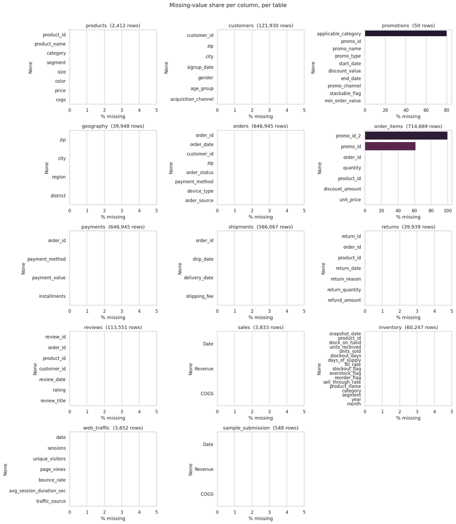

```python
missing = pd.DataFrame({
    name: [df.isna().mean().mean() * 100] for name, df in tables.items()
}, index=['overall_missing_%']).T.sort_values('overall_missing_%', ascending=False)
display(missing)

fig, axes = plt.subplots(nrows=5, ncols=3, figsize=(16, 18))
axes = axes.flatten()
for ax, (name, df) in zip(axes, tables.items()):
    miss = df.isna().mean().sort_values(ascending=False) * 100
    sns.barplot(x=miss.values, y=miss.index, ax=ax, palette='rocket')
    ax.set_title(f'{name}  ({df.shape[0]:,} rows)')
    ax.set_xlabel('% missing')
    ax.set_xlim(0, max(miss.max() + 5, 5))
for ax in axes[len(tables):]:
    ax.axis('off')
plt.suptitle('Missing-value share per column, per table', fontsize=14, y=1.01)
plt.tight_layout()
savefig('02_missing_values_heatmap.png')
plt.show()
```

## 3 — Products Catalog

What categories / segments / sizes / colors / price bands make up the catalog? Price vs COGS implies margin.

```python
products = tables['products'].copy()
products['margin']     = products['price'] - products['cogs']
products['margin_pct'] = products['margin'] / products['price']
display(products.head())
display(products.describe(include='all').T)
```

|  | product_id | product_name | category | segment | size | color | price | cogs | margin | margin_pct |
| --- | --- | --- | --- | --- | --- | --- | --- | --- | --- | --- |
| 0 | 536 | SaigonFlex UC-01 | Streetwear | Everyday | S | green | 11,059.65 | 9,704.84 | 1,354.81 | 0.12 |
| 1 | 537 | SaigonFlex UC-02 | Streetwear | Everyday | M | silver | 9,523.08 | 5,393.87 | 4,129.21 | 0.43 |
| 2 | 538 | SaigonFlex UC-03 | Streetwear | Everyday | L | pink | 15,951.63 | 11,371.92 | 4,579.71 | 0.29 |
| 3 | 539 | SaigonFlex UC-04 | Streetwear | Everyday | XL | yellow | 15,753.72 | 8,573.17 | 7,180.54 | 0.46 |
| 4 | 540 | SaigonFlex UC-05 | Streetwear | Everyday | S | red | 15,766.33 | 14,063.57 | 1,702.76 | 0.11 |

|  | count | unique | top | freq | mean | std | min | 25% | 50% | 75% | max |
| --- | --- | --- | --- | --- | --- | --- | --- | --- | --- | --- | --- |
| product_id | 2,412.00 | NaN | NaN | NaN | 1,206.50 | 696.43 | 1.00 | 603.75 | 1,206.50 | 1,809.25 | 2,412.00 |
| product_name | 2412 | 2172 | VietMode RP-01 | 3 | NaN | NaN | NaN | NaN | NaN | NaN | NaN |
| category | 2412 | 4 | Streetwear | 1320 | NaN | NaN | NaN | NaN | NaN | NaN | NaN |
| segment | 2412 | 8 | Activewear | 598 | NaN | NaN | NaN | NaN | NaN | NaN | NaN |
| size | 2412 | 4 | S | 603 | NaN | NaN | NaN | NaN | NaN | NaN | NaN |
| color | 2412 | 10 | black | 242 | NaN | NaN | NaN | NaN | NaN | NaN | NaN |
| price | 2,412.00 | NaN | NaN | NaN | 4,928.22 | 4,776.74 | 9.06 | 59.44 | 4,399.60 | 7,720.51 | 40,950.00 |
| cogs | 2,412.00 | NaN | NaN | NaN | 3,868.35 | 3,878.58 | 5.18 | 35.07 | 3,184.93 | 5,864.92 | 38,902.50 |
| margin | 2,412.00 | NaN | NaN | NaN | 1,059.87 | 1,422.07 | 3.87 | 23.55 | 490.87 | 1,553.39 | 13,118.39 |
| margin_pct | 2,412.00 | NaN | NaN | NaN | 0.27 | 0.15 | 0.05 | 0.10 | 0.31 | 0.40 | 0.50 |

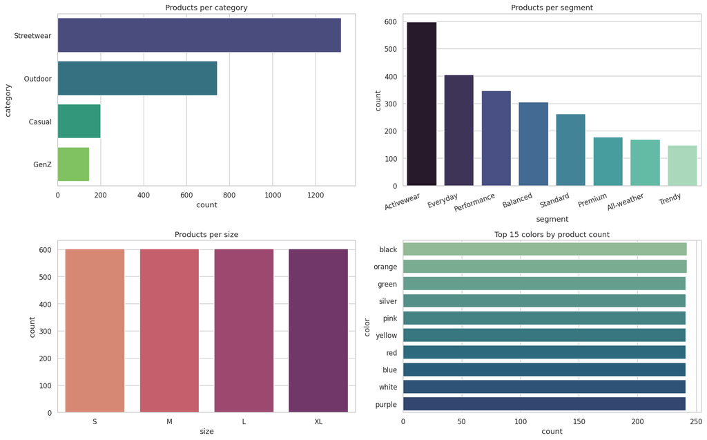

```python
fig, axes = plt.subplots(2, 2, figsize=(16, 10))

sns.countplot(
    data=products,
    y='category',
    order=products['category'].value_counts().index,
    ax=axes[0, 0],
    palette='viridis'
)
axes[0, 0].set_title('Products per category')
axes[0, 0].set_xlabel('count')
axes[0, 0].set_ylabel('category')

sns.countplot(
    data=products,
    x='segment',
    order=products['segment'].value_counts().index,
    ax=axes[0, 1],
    palette='mako'
)
axes[0, 1].set_title('Products per segment')
axes[0, 1].set_xlabel('segment')
axes[0, 1].set_ylabel('count')
axes[0, 1].tick_params(axis='x', rotation=20)   # xoay label để không đè nhau
axes[0, 1].set_xticklabels(axes[0, 1].get_xticklabels(), ha='right')

sns.countplot(
    data=products,
    x='size',
    order=['S', 'M', 'L', 'XL'],
    ax=axes[1, 0],
    palette='flare'
)
axes[1, 0].set_title('Products per size')
axes[1, 0].set_xlabel('size')
axes[1, 0].set_ylabel('count')

top_colors = products['color'].value_counts().head(15)
sns.barplot(
    x=top_colors.values,
    y=top_colors.index,
    ax=axes[1, 1],
    palette='crest'
)
axes[1, 1].set_title('Top 15 colors by product count')
axes[1, 1].set_xlabel('count')
axes[1, 1].set_ylabel('color')

plt.tight_layout()
plt.savefig('03_products_category_segment_size.png', dpi=300, bbox_inches='tight')
plt.show()
```

| segment category | Activewear | All-weather | Balanced | Everyday | Performance | Premium | Standard | Trendy |
| --- | --- | --- | --- | --- | --- | --- | --- | --- |
| Casual | 0.29 | 0.28 | NaN | NaN | NaN | NaN | NaN | NaN |
| GenZ | NaN | NaN | NaN | NaN | NaN | NaN | NaN | 0.24 |
| Outdoor | 0.26 | NaN | NaN | NaN | NaN | 0.28 | NaN | NaN |
| Streetwear | NaN | NaN | 0.26 | 0.24 | 0.26 | NaN | 0.31 | NaN |

```
Saved -> images/04_margin_category_segment_heatmap.png
```

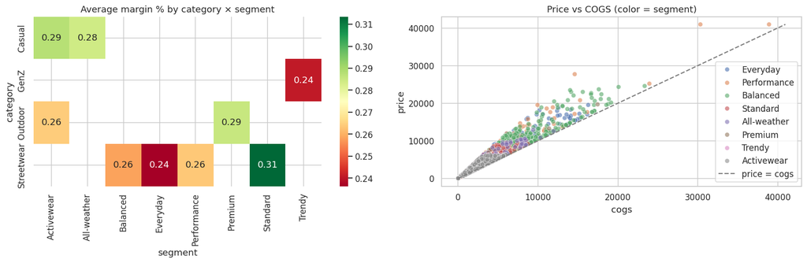

```python
margin_heat = (products.groupby(['category', 'segment'])['margin_pct']
                        .mean().unstack())
display(margin_heat.round(3))

fig, axes = plt.subplots(1, 2, figsize=(15, 5))
sns.heatmap(margin_heat, annot=True, fmt='.2f', cmap='RdYlGn', ax=axes[0])
axes[0].set_title('Average margin % by category × segment')

sns.scatterplot(data=products, x='cogs', y='price', hue='segment',
                alpha=0.6, ax=axes[1])
axes[1].plot([0, products['price'].max()], [0, products['price'].max()],
             color='grey', ls='--', label='price = cogs')
axes[1].set_title('Price vs COGS (color = segment)')
axes[1].legend()
plt.tight_layout()
savefig('04_margin_category_segment_heatmap.png')
plt.show()
```

## 4 — Customers

Signup trajectory, gender / age / acquisition-channel mix.

|  | customer_id | zip | city | signup_date | gender | age_group | acquisition_channel |
| --- | --- | --- | --- | --- | --- | --- | --- |
| 0 | 1 | 15201 | Hai Phong | 2021-12-30 | Female | 35-44 | social_media |
| 1 | 2 | 15201 | Hai Phong | 2013-12-27 | Female | 45-54 | email_campaign |
| 2 | 3 | 15201 | Hai Phong | 2018-07-24 | Female | 18-24 | organic_search |
| 3 | 4 | 15201 | Hai Phong | 2017-11-29 | Male | 35-44 | referral |
| 4 | 5 | 15201 | Hai Phong | 2022-09-23 | Male | 55+ | organic_search |

|  | count | unique | top | freq | mean | min | 25% | 50% | 75% | max | std |
| --- | --- | --- | --- | --- | --- | --- | --- | --- | --- | --- | --- |
| customer_id | 121,930.00 | NaN | NaN | NaN | 78,736.90 | 1.00 | 39,343.50 | 78,784.50 | 118,156.75 | 157,563.00 | 45,492.20 |
| zip | 121,930.00 | NaN | NaN | NaN | 50,990.17 | 1,001.00 | 28,689.25 | 49,835.00 | 73,488.00 | 99,950.00 | 26,871.91 |
| city | 121930 | 42 | Cam Pha | 4398 | NaN | NaN | NaN | NaN | NaN | NaN | NaN |
| signup_date | 121930 | NaN | NaN | NaN | 2019-05-02 06:41:34.637907 | 2012-01-17 00:00:00 | 2017-06-27 00:00:00 | 2019-10-12 00:00:00 | 2021-07-11 00:00:00 | 2022-12-31 00:00:00 | NaN |
| gender | 121930 | 3 | Female | 59640 | NaN | NaN | NaN | NaN | NaN | NaN | NaN |
| age_group | 121930 | 5 | 25-34 | 36342 | NaN | NaN | NaN | NaN | NaN | NaN | NaN |
| acquisition_channel | 121930 | 6 | organic_search | 36450 | NaN | NaN | NaN | NaN | NaN | NaN | NaN |

```
Saved -> images/05_customers_signups_gender_channel.png
```

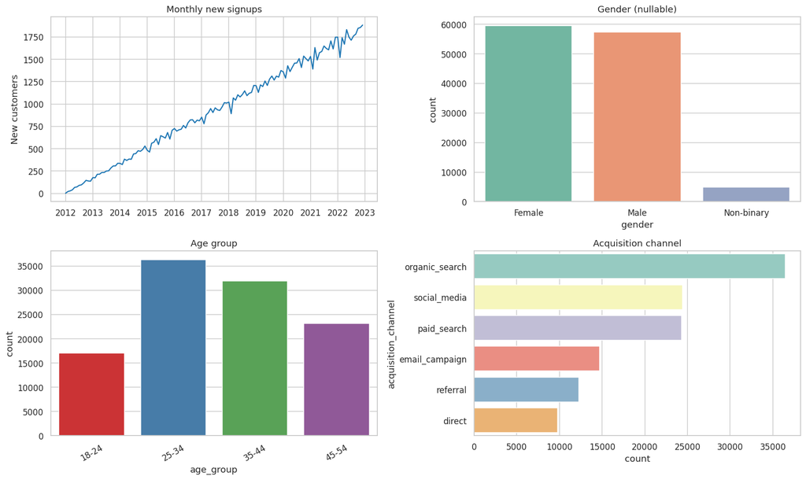

```python
customers = tables['customers'].copy()
display(customers.head())
display(customers.describe(include='all').T)

customers['signup_year_month'] = customers['signup_date'].dt.to_period('M').dt.to_timestamp()
signup_trend = customers.groupby('signup_year_month').size()

fig, axes = plt.subplots(2, 2, figsize=(15, 9))

axes[0, 0].plot(signup_trend.index, signup_trend.values, color='tab:blue')
axes[0, 0].set_title('Monthly new signups')
axes[0, 0].set_ylabel('New customers')
axes[0, 0].xaxis.set_major_locator(mdates.YearLocator())
axes[0, 0].xaxis.set_major_formatter(mdates.DateFormatter('%Y'))

sns.countplot(data=customers, x='gender',
              order=customers['gender'].value_counts().index,
              ax=axes[0, 1], palette='Set2')
axes[0, 1].set_title('Gender (nullable)')

age_order = ['<18', '18-24', '25-34', '35-44', '45-54', '55-64', '65+']
present = [a for a in age_order if a in customers['age_group'].dropna().unique()]
if not present:
    present = customers['age_group'].value_counts().index.tolist()
sns.countplot(data=customers, x='age_group', order=present, ax=axes[1, 0], palette='Set1')
axes[1, 0].set_title('Age group')
axes[1, 0].tick_params(axis='x', rotation=30)

sns.countplot(data=customers, y='acquisition_channel',
              order=customers['acquisition_channel'].value_counts().index,
              ax=axes[1, 1], palette='Set3')
axes[1, 1].set_title('Acquisition channel')

plt.tight_layout()
savefig('05_customers_signups_gender_channel.png')
plt.show()
```

## 5 — Promotions

How many campaigns, of what type, channel, duration, and discount depth?

```python
promo = tables['promotions'].copy()
promo['duration_days'] = (promo['end_date'] - promo['start_date']).dt.days
display(promo.head())
display(promo.describe(include='all').T)
```

|  | promo_id | promo_name | promo_type | discount_value | start_date | end_date | applicable_category | promo_channel | stackable_flag | min_order_value | duration_days |
| --- | --- | --- | --- | --- | --- | --- | --- | --- | --- | --- | --- |
| 0 | PROMO-0001 | Spring Sale 2013 | percentage | 12.00 | 2013-03-18 | 2013-04-17 | NaN | email | 1 | 0 | 30 |
| 1 | PROMO-0002 | Mid-Year Sale 2013 | percentage | 18.00 | 2013-06-23 | 2013-07-22 | NaN | online | 0 | 0 | 29 |
| 2 | PROMO-0003 | Fall Launch 2013 | percentage | 10.00 | 2013-08-30 | 2013-10-02 | NaN | email | 0 | 0 | 33 |
| 3 | PROMO-0004 | Year-End Sale 2013 | percentage | 20.00 | 2013-11-18 | 2014-01-02 | NaN | all_channels | 0 | 50000 | 45 |
| 4 | PROMO-0005 | Urban Blowout 2013 | fixed | 50.00 | 2013-07-30 | 2013-09-02 | Streetwear | online | 0 | 150000 | 34 |

|  | count | unique | top | freq | mean | min | 25% | 50% | 75% | max | std |
| --- | --- | --- | --- | --- | --- | --- | --- | --- | --- | --- | --- |
| promo_id | 50 | 50 | PROMO-0001 | 1 | NaN | NaN | NaN | NaN | NaN | NaN | NaN |
| promo_name | 50 | 50 | Spring Sale 2013 | 1 | NaN | NaN | NaN | NaN | NaN | NaN | NaN |
| promo_type | 50 | 2 | percentage | 45 | NaN | NaN | NaN | NaN | NaN | NaN | NaN |
| discount_value | 50.00 | NaN | NaN | NaN | 18.50 | 10.00 | 12.00 | 16.50 | 20.00 | 50.00 | 11.24 |
| start_date | 50 | NaN | NaN | NaN | 2017-11-29 02:52:48 | 2013-01-31 00:00:00 | 2015-07-02 06:00:00 | 2017-10-09 00:00:00 | 2020-05-29 18:00:00 | 2022-11-18 00:00:00 | NaN |
| end_date | 50 | NaN | NaN | NaN | 2018-01-01 15:50:24 | 2013-03-01 00:00:00 | 2015-08-01 12:00:00 | 2017-11-17 00:00:00 | 2020-06-28 00:00:00 | 2022-12-31 00:00:00 | NaN |
| applicable_category | 10 | 2 | Streetwear | 5 | NaN | NaN | NaN | NaN | NaN | NaN | NaN |
| promo_channel | 50 | 5 | all_channels | 19 | NaN | NaN | NaN | NaN | NaN | NaN | NaN |
| stackable_flag | 50.00 | NaN | NaN | NaN | 0.24 | 0.00 | 0.00 | 0.00 | 0.00 | 1.00 | 0.43 |
| min_order_value | 50.00 | NaN | NaN | NaN | 46,000.00 | 0.00 | 0.00 | 0.00 | 100,000.00 | 200,000.00 | 66,116.78 |
| duration_days | 50.00 | NaN | NaN | NaN | 33.54 | 29.00 | 30.00 | 30.50 | 34.00 | 45.00 | 5.81 |

```
Saved -> images/06_promo_type_channel_duration.png
```

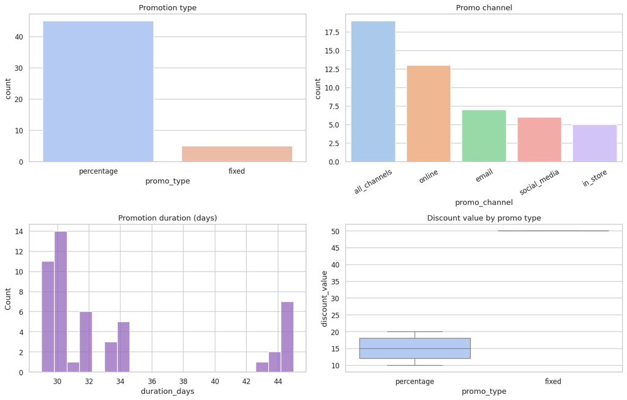

```python
fig, axes = plt.subplots(2, 2, figsize=(14, 9))

sns.countplot(data=promo, x='promo_type', ax=axes[0, 0], palette='coolwarm')
axes[0, 0].set_title('Promotion type')

sns.countplot(data=promo, x='promo_channel',
              order=promo['promo_channel'].value_counts().index,
              ax=axes[0, 1], palette='pastel')
axes[0, 1].set_title('Promo channel')
axes[0, 1].tick_params(axis='x', rotation=30)

sns.histplot(promo['duration_days'].dropna(), bins=20, ax=axes[1, 0], color='tab:purple')
axes[1, 0].set_title('Promotion duration (days)')

sns.boxplot(data=promo, x='promo_type', y='discount_value', ax=axes[1, 1], palette='coolwarm')
axes[1, 1].set_title('Discount value by promo type')

plt.tight_layout()
savefig('06_promo_type_channel_duration.png')
plt.show()
```

## 6 — Geography & Orders by Region

| region | orders |
| --- | --- |
| East | 294612 |
| Central | 184691 |
| West | 167642 |

```
Saved -> images/07_orders_by_region.png
```

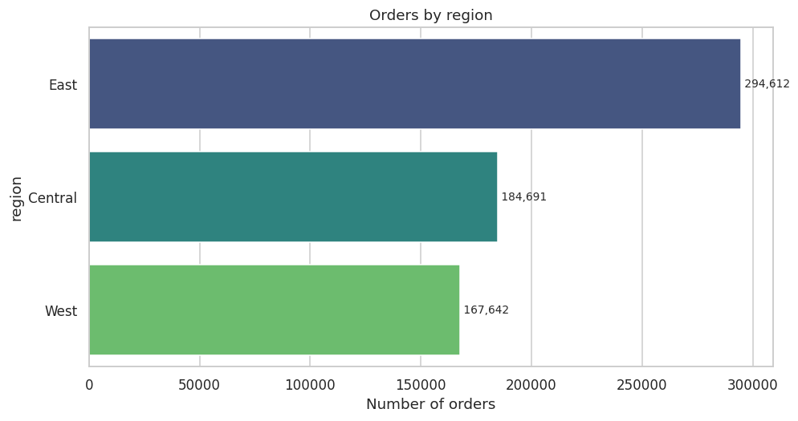

```python
orders    = tables['orders'].copy()
geography = tables['geography'].copy()

orders_geo = orders.merge(geography[['zip', 'region']], on='zip', how='left')
region_counts = orders_geo['region'].value_counts(dropna=False)
display(region_counts.to_frame('orders'))

fig, ax = plt.subplots(figsize=(10, 5))
sns.barplot(x=region_counts.values, y=region_counts.index.astype(str), ax=ax, palette='viridis')
ax.set_title('Orders by region')
ax.set_xlabel('Number of orders')
for i, v in enumerate(region_counts.values):
    ax.text(v, i, f' {v:,}', va='center', fontsize=9)
savefig('07_orders_by_region.png')
plt.show()
```

## 7 — Orders: categorical distributions & temporal patterns

```
Saved -> images/08_orders_categorical_distributions.png
```

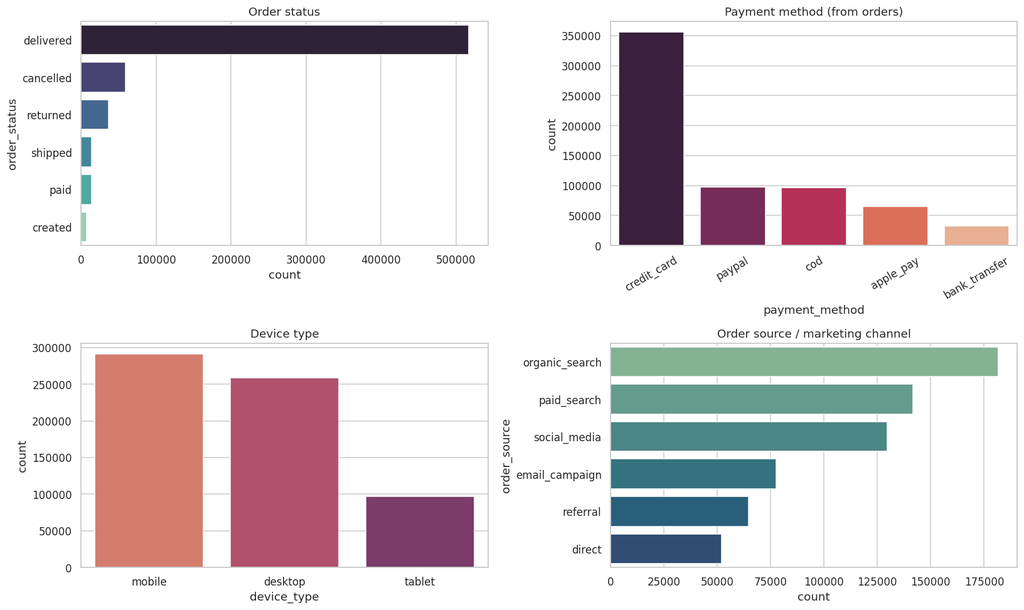

```python
fig, axes = plt.subplots(2, 2, figsize=(15, 9))

sns.countplot(data=orders, y='order_status',
              order=orders['order_status'].value_counts().index,
              ax=axes[0, 0], palette='mako')
axes[0, 0].set_title('Order status')

sns.countplot(data=orders, x='payment_method',
              order=orders['payment_method'].value_counts().index,
              ax=axes[0, 1], palette='rocket')
axes[0, 1].set_title('Payment method (from orders)')
axes[0, 1].tick_params(axis='x', rotation=30)

sns.countplot(data=orders, x='device_type',
              order=orders['device_type'].value_counts().index,
              ax=axes[1, 0], palette='flare')
axes[1, 0].set_title('Device type')

sns.countplot(data=orders, y='order_source',
              order=orders['order_source'].value_counts().index,
              ax=axes[1, 1], palette='crest')
axes[1, 1].set_title('Order source / marketing channel')

plt.tight_layout()
savefig('08_orders_categorical_distributions.png')
plt.show()
```

```
Saved -> images/09_orders_yearly_dow.png
```

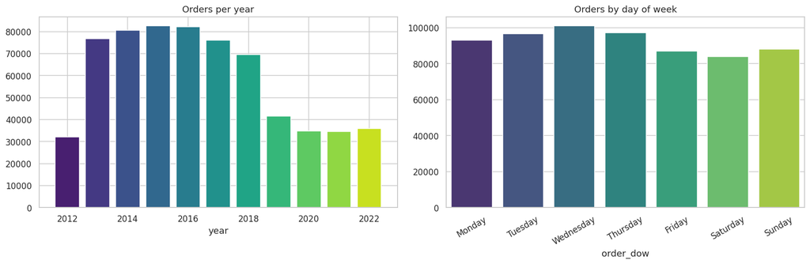

| order_year | orders |
| --- | --- |
| 2012 | 32051 |
| 2013 | 76849 |
| 2014 | 80645 |
| 2015 | 82622 |
| 2016 | 82247 |
| 2017 | 76010 |
| 2018 | 69510 |
| 2019 | 41601 |
| 2020 | 34881 |
| 2021 | 34525 |
| 2022 | 36004 |

```python
orders['order_year'] = orders['order_date'].dt.year
orders['order_dow']  = orders['order_date'].dt.day_name()

yearly = orders.groupby('order_year').size()
dow_order = ['Monday', 'Tuesday', 'Wednesday', 'Thursday', 'Friday', 'Saturday', 'Sunday']
dow = orders['order_dow'].value_counts().reindex(dow_order)

fig, axes = plt.subplots(1, 2, figsize=(15, 5))
axes[0].bar(yearly.index, yearly.values, color=sns.color_palette('viridis', len(yearly)))
axes[0].set_title('Orders per year')
axes[0].set_xlabel('year')

sns.barplot(x=dow.index, y=dow.values, ax=axes[1], palette='viridis')
axes[1].set_title('Orders by day of week')
axes[1].tick_params(axis='x', rotation=30)

plt.tight_layout()
savefig('09_orders_yearly_dow.png')
plt.show()

display(yearly.to_frame('orders'))
```

## 8 — Order items: quantity, unit_price, discount

We compute `line_revenue = quantity * unit_price` and the discount share.

```python
order_items = tables['order_items'].copy()
order_items['line_revenue'] = order_items['quantity'] * order_items['unit_price']
order_items['has_promo']    = order_items['promo_id'].notna()
display(order_items.head())
display(order_items[['quantity', 'unit_price', 'discount_amount', 'line_revenue']].describe())
```

|  | order_id | product_id | quantity | unit_price | discount_amount | promo_id | promo_id_2 | line_revenue | has_promo |
| --- | --- | --- | --- | --- | --- | --- | --- | --- | --- |
| 0 | 1 | 2400 | 7 | 1,138.22 | 0.00 | NaN | NaN | 7,967.54 | False |
| 1 | 2 | 609 | 7 | 10,166.25 | 0.00 | NaN | NaN | 71,163.75 | False |
| 2 | 3 | 396 | 3 | 11,220.33 | 0.00 | NaN | NaN | 33,660.99 | False |
| 3 | 4 | 635 | 5 | 10,639.25 | 0.00 | NaN | NaN | 53,196.25 | False |
| 4 | 6 | 1935 | 1 | 1,597.84 | 0.00 | NaN | NaN | 1,597.84 | False |

|  | quantity | unit_price | discount_amount | line_revenue |
| --- | --- | --- | --- | --- |
| count | 714,669.00 | 714,669.00 | 714,669.00 | 714,669.00 |
| mean | 4.50 | 5,114.69 | 1,048.89 | 22,990.33 |
| std | 2.29 | 3,774.82 | 2,280.53 | 22,352.46 |
| min | 1.00 | 392.57 | 0.00 | 442.89 |
| 25% | 2.00 | 1,906.89 | 0.00 | 6,497.97 |
| 50% | 4.00 | 4,257.77 | 0.00 | 15,442.12 |
| 75% | 6.00 | 7,273.76 | 967.63 | 32,016.64 |
| max | 8.00 | 43,056.00 | 35,235.47 | 331,570.40 |

```
Saved -> images/10_order_items_histograms.png
```

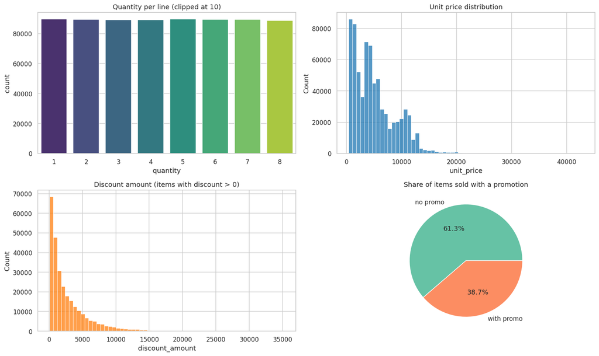

```python
fig, axes = plt.subplots(2, 2, figsize=(15, 9))

sns.countplot(x=order_items['quantity'].clip(upper=10), ax=axes[0, 0], palette='viridis')
axes[0, 0].set_title('Quantity per line (clipped at 10)')

sns.histplot(order_items['unit_price'], bins=60, ax=axes[0, 1], color='tab:blue')
axes[0, 1].set_title('Unit price distribution')

sns.histplot(order_items.loc[order_items['discount_amount'] > 0, 'discount_amount'],
             bins=60, ax=axes[1, 0], color='tab:orange')
axes[1, 0].set_title('Discount amount (items with discount > 0)')

promo_share = order_items['has_promo'].value_counts(normalize=True) * 100
axes[1, 1].pie(promo_share.values, labels=['with promo' if k else 'no promo' for k in promo_share.index],
               autopct='%1.1f%%', colors=sns.color_palette('Set2'))
axes[1, 1].set_title('Share of items sold with a promotion')

plt.tight_layout()
savefig('10_order_items_histograms.png')
plt.show()
```

| segment category | Activewear | All-weather | Balanced | Everyday | Performance | Premium | Standard | Trendy |
| --- | --- | --- | --- | --- | --- | --- | --- | --- |
| Casual | 33,063,858.00 | 427,584,525.00 | 0.00 | 0.00 | 0.00 | 0.00 | 0.00 | 0.00 |
| GenZ | 0.00 | 0.00 | 0.00 | 0.00 | 0.00 | 0.00 | 0.00 | 343,599,095.00 |
| Outdoor | 2,014,751,366.00 | 0.00 | 0.00 | 0.00 | 0.00 | 480,131,388.00 | 0.00 | 0.00 |
| Streetwear | 0.00 | 0.00 | 5,127,408,523.00 | 5,376,848,662.00 | 2,390,412,021.00 | 0.00 | 236,677,146.00 | 0.00 |

```
Saved -> images/11_revenue_by_category_segment.png
```

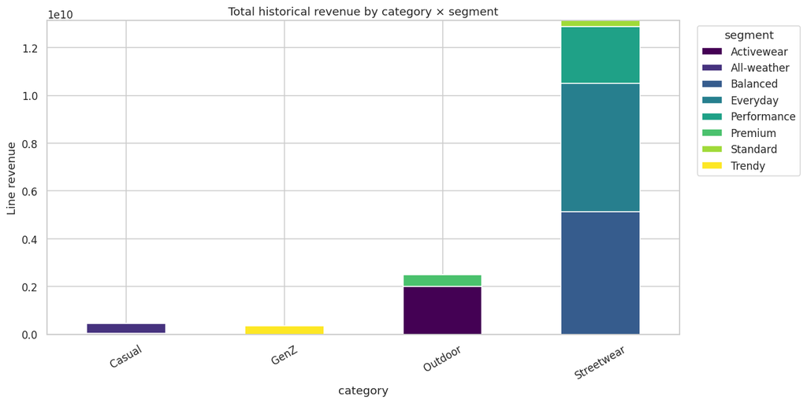

```python
items_prod = order_items.merge(products[['product_id', 'category', 'segment']],
                               on='product_id', how='left')

rev_cat_seg = (items_prod.groupby(['category', 'segment'])['line_revenue']
                          .sum().unstack().fillna(0))
display(rev_cat_seg.round(0))

fig, ax = plt.subplots(figsize=(12, 6))
rev_cat_seg.plot(kind='bar', stacked=True, ax=ax, colormap='viridis')
ax.set_title('Total historical revenue by category × segment')
ax.set_ylabel('Line revenue')
ax.tick_params(axis='x', rotation=30)
ax.legend(title='segment', bbox_to_anchor=(1.02, 1), loc='upper left')
savefig('11_revenue_by_category_segment.png')
plt.show()
```

## 9 — Payments

|  | order_id | payment_method | payment_value | installments |
| --- | --- | --- | --- | --- |
| 0 | 1 | credit_card | 7,967.54 | 3 |
| 1 | 2 | cod | 71,163.75 | 1 |
| 2 | 3 | credit_card | 33,660.99 | 3 |
| 3 | 4 | credit_card | 53,196.25 | 3 |
| 4 | 6 | paypal | 1,597.84 | 1 |

|  | count | unique | top | freq | mean | std | min | 25% | 50% | 75% | max |
| --- | --- | --- | --- | --- | --- | --- | --- | --- | --- | --- | --- |
| order_id | 646,945.00 | NaN | NaN | NaN | 417,189.47 | 240,785.70 | 1.00 | 208,728.00 | 417,211.00 | 625,628.00 | 834,397.00 |
| payment_method | 646945 | 5 | credit_card | 356352 | NaN | NaN | NaN | NaN | NaN | NaN | NaN |
| payment_value | 646,945.00 | NaN | NaN | NaN | 24,238.33 | 22,378.48 | 389.74 | 7,681.06 | 17,229.44 | 33,706.35 | 331,570.40 |
| installments | 646,945.00 | NaN | NaN | NaN | 3.45 | 3.12 | 1.00 | 1.00 | 3.00 | 6.00 | 12.00 |

```
Saved -> images/12_payments_method_installments.png
```

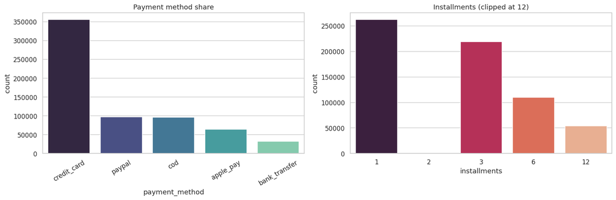

```python
payments = tables['payments'].copy()
display(payments.head())
display(payments.describe(include='all').T)

fig, axes = plt.subplots(1, 2, figsize=(15, 5))
sns.countplot(data=payments, x='payment_method',
              order=payments['payment_method'].value_counts().index,
              ax=axes[0], palette='mako')
axes[0].set_title('Payment method share')
axes[0].tick_params(axis='x', rotation=30)

sns.countplot(x=payments['installments'].clip(upper=12), ax=axes[1], palette='rocket')
axes[1].set_title('Installments (clipped at 12)')

plt.tight_layout()
savefig('12_payments_method_installments.png')
plt.show()
```

## 10 — Shipments: delivery time & fees

|  | order_id | ship_date | delivery_date | shipping_fee | delivery_days |
| --- | --- | --- | --- | --- | --- |
| 0 | 1 | 2012-07-07 | 2012-07-11 | 1.37 | 4 |
| 1 | 2 | 2012-07-06 | 2012-07-10 | 2.60 | 4 |
| 2 | 3 | 2012-07-04 | 2012-07-07 | 2.38 | 3 |
| 3 | 4 | 2012-07-05 | 2012-07-11 | 2.49 | 6 |
| 4 | 6 | 2012-07-09 | 2012-07-16 | 25.79 | 7 |

|  | shipping_fee | delivery_days |
| --- | --- | --- |
| count | 566,067.00 | 566,067.00 |
| mean | 4.96 | 4.50 |
| std | 8.89 | 1.71 |
| min | 0.00 | 2.00 |
| 25% | 0.87 | 3.00 |
| 50% | 1.73 | 4.00 |
| 75% | 2.60 | 6.00 |
| max | 32.00 | 7.00 |

```
Saved -> images/13_shipments_delivery_fee.png
```

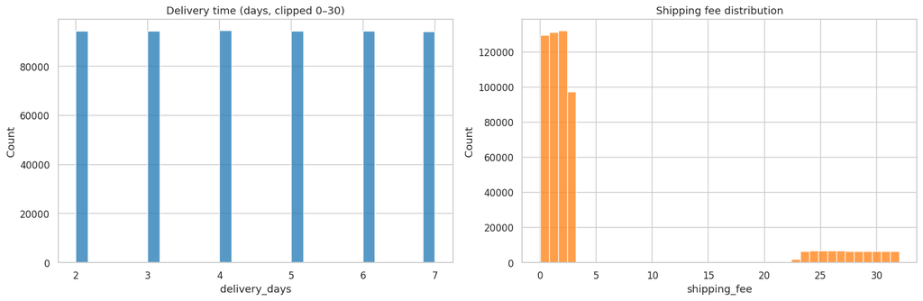

```python
shipments = tables['shipments'].copy()
shipments['delivery_days'] = (shipments['delivery_date'] - shipments['ship_date']).dt.days
display(shipments.head())
display(shipments[['shipping_fee', 'delivery_days']].describe())

fig, axes = plt.subplots(1, 2, figsize=(15, 5))
sns.histplot(shipments['delivery_days'].dropna().clip(lower=0, upper=30),
             bins=30, ax=axes[0], color='tab:blue')
axes[0].set_title('Delivery time (days, clipped 0–30)')

sns.histplot(shipments['shipping_fee'].dropna(), bins=40, ax=axes[1], color='tab:orange')
axes[1].set_title('Shipping fee distribution')

plt.tight_layout()
savefig('13_shipments_delivery_fee.png')
plt.show()
```

## 11 — Returns: reasons, yearly refund value

|  | return_id | order_id | product_id | return_date | return_reason | return_quantity | refund_amount | return_year |
| --- | --- | --- | --- | --- | --- | --- | --- | --- |
| 0 | RET-000001 | 2 | 609 | 2012-07-25 | late_delivery | 6 | 52,458.01 | 2012 |
| 1 | RET-000002 | 32 | 1862 | 2012-07-16 | wrong_size | 2 | 5,141.37 | 2012 |
| 2 | RET-000003 | 35 | 2359 | 2012-07-16 | wrong_size | 1 | 5,315.95 | 2012 |
| 3 | RET-000004 | 47 | 1449 | 2012-07-11 | wrong_size | 4 | 6,493.75 | 2012 |
| 4 | RET-000005 | 47 | 1450 | 2012-07-25 | wrong_size | 1 | 1,740.76 | 2012 |

|  | count | unique | top | freq | mean | min | 25% | 50% | 75% | max | std |
| --- | --- | --- | --- | --- | --- | --- | --- | --- | --- | --- | --- |
| return_id | 39939 | 39939 | RET-000001 | 1 | NaN | NaN | NaN | NaN | NaN | NaN | NaN |
| order_id | 39,939.00 | NaN | NaN | NaN | 409,061.98 | 2.00 | 202,651.00 | 404,254.00 | 615,620.00 | 833,351.00 | 240,063.90 |
| product_id | 39,939.00 | NaN | NaN | NaN | 1,244.23 | 3.00 | 702.00 | 992.00 | 2,048.00 | 2,412.00 | 691.75 |
| return_date | 39939 | NaN | NaN | NaN | 2016-11-11 22:20:33.621272 | 2012-07-11 00:00:00 | 2014-08-05 00:00:00 | 2016-07-06 00:00:00 | 2018-08-08 00:00:00 | 2022-12-31 00:00:00 | NaN |
| return_reason | 39939 | 5 | wrong_size | 13967 | NaN | NaN | NaN | NaN | NaN | NaN | NaN |
| return_quantity | 39,939.00 | NaN | NaN | NaN | 2.74 | 1.00 | 1.00 | 2.00 | 4.00 | 8.00 | 1.83 |
| refund_amount | 39,939.00 | NaN | NaN | NaN | 12,784.46 | 458.81 | 3,573.39 | 7,888.88 | 16,881.99 | 160,937.94 | 14,092.15 |
| return_year | 39,939.00 | NaN | NaN | NaN | 2,016.37 | 2,012.00 | 2,014.00 | 2,016.00 | 2,018.00 | 2,022.00 | 2.73 |

```
Saved -> images/14_returns_reasons_yearly_refund.png
```

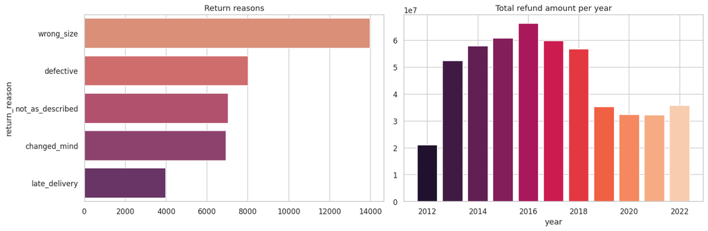

```python
returns = tables['returns'].copy()
returns['return_year'] = returns['return_date'].dt.year
display(returns.head())
display(returns.describe(include='all').T)

reasons = returns['return_reason'].value_counts()
yearly_refund = returns.groupby('return_year')['refund_amount'].sum()

fig, axes = plt.subplots(1, 2, figsize=(15, 5))
sns.barplot(x=reasons.values, y=reasons.index, ax=axes[0], palette='flare')
axes[0].set_title('Return reasons')

axes[1].bar(yearly_refund.index.astype(int), yearly_refund.values,
            color=sns.color_palette('rocket', len(yearly_refund)))
axes[1].set_title('Total refund amount per year')
axes[1].set_xlabel('year')

plt.tight_layout()
savefig('14_returns_reasons_yearly_refund.png')
plt.show()
```

## 12 — Reviews: rating distribution

|  | review_id | order_id | product_id | customer_id | review_date | rating | review_title |
| --- | --- | --- | --- | --- | --- | --- | --- |
| 0 | REV-0000001 | 1 | 2400 | 58578 | 2012-07-24 | 5 | Highly recommend |
| 1 | REV-0000002 | 3 | 396 | 58811 | 2012-08-03 | 5 | Very satisfied |
| 2 | REV-0000003 | 10 | 1431 | 49101 | 2012-07-23 | 5 | Great quality |
| 3 | REV-0000005 | 16 | 1668 | 41028 | 2012-08-05 | 5 | Great quality |
| 4 | REV-0000006 | 17 | 2352 | 42030 | 2012-07-17 | 4 | Good overall |

```
count   113,551.00
mean          3.94
std           1.15
min           1.00
25%           3.00
50%           4.00
75%           5.00
max           5.00
Name: rating, dtype: float64
```

```
Saved -> images/15_reviews_rating_distribution.png
```

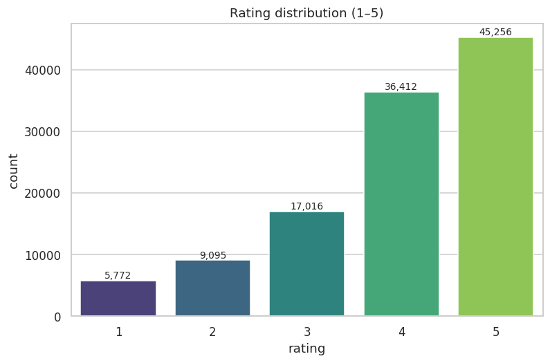

```python
reviews = tables['reviews'].copy()
display(reviews.head())
display(reviews['rating'].describe())

fig, ax = plt.subplots(figsize=(8, 5))
sns.countplot(data=reviews, x='rating', order=sorted(reviews['rating'].dropna().unique()),
              ax=ax, palette='viridis')
ax.set_title('Rating distribution (1–5)')
for p in ax.patches:
    ax.annotate(f'{int(p.get_height()):,}',
                (p.get_x() + p.get_width() / 2, p.get_height()),
                ha='center', va='bottom', fontsize=9)
savefig('15_reviews_rating_distribution.png')
plt.show()
```

## 13 — Sales (the forecasting target)

`sales.csv` is the analytical table we must forecast. We inspect Revenue, COGS, and derived margin.

```python
sales = tables['sales'].copy().sort_values('Date').reset_index(drop=True)
sales['margin']     = sales['Revenue'] - sales['COGS']
sales['margin_pct'] = sales['margin'] / sales['Revenue']
sales['year']       = sales['Date'].dt.year
sales['month']      = sales['Date'].dt.month
sales['dow']        = sales['Date'].dt.day_name()
display(sales.head())
display(sales.describe().T)
display(Markdown(f'**Date range:** {sales["Date"].min().date()} → {sales["Date"].max().date()}  \n'
                 f'**Total days:** {len(sales):,}  (expected {((sales["Date"].max() - sales["Date"].min()).days + 1):,})'))
```

|  | Date | Revenue | COGS | margin | margin_pct | year | month | dow |
| --- | --- | --- | --- | --- | --- | --- | --- | --- |
| 0 | 2012-07-04 | 5,123,547.94 | 3,982,991.19 | 1,140,556.75 | 0.22 | 2012 | 7 | Wednesday |
| 1 | 2012-07-05 | 2,751,773.45 | 2,150,580.23 | 601,193.22 | 0.22 | 2012 | 7 | Thursday |
| 2 | 2012-07-06 | 3,054,029.42 | 2,517,632.84 | 536,396.58 | 0.18 | 2012 | 7 | Friday |
| 3 | 2012-07-07 | 2,667,930.94 | 2,108,246.62 | 559,684.32 | 0.21 | 2012 | 7 | Saturday |
| 4 | 2012-07-08 | 2,360,851.90 | 1,808,622.79 | 552,229.11 | 0.23 | 2012 | 7 | Sunday |

|  | count | mean | min | 25% | 50% | 75% | max | std |
| --- | --- | --- | --- | --- | --- | --- | --- | --- |
| Date | 3833 | 2017-10-02 00:00:00 | 2012-07-04 00:00:00 | 2015-02-17 00:00:00 | 2017-10-02 00:00:00 | 2020-05-17 00:00:00 | 2022-12-31 00:00:00 | NaN |
| Revenue | 3,833.00 | 4,286,584.03 | 279,813.94 | 2,471,088.82 | 3,647,303.90 | 5,350,877.20 | 20,905,271.35 | 2,624,840.20 |
| COGS | 3,833.00 | 3,695,134.49 | 236,576.31 | 2,150,580.23 | 3,161,112.99 | 4,637,293.92 | 16,535,857.67 | 2,219,788.77 |
| margin | 3,833.00 | 591,449.53 | -2,567,311.72 | 229,274.05 | 544,554.38 | 876,080.98 | 4,369,413.68 | 666,196.02 |
| margin_pct | 3,833.00 | 0.13 | -0.57 | 0.08 | 0.18 | 0.20 | 0.29 | 0.13 |
| year | 3,833.00 | 2,017.24 | 2,012.00 | 2,015.00 | 2,017.00 | 2,020.00 | 2,022.00 | 3.04 |
| month | 3,833.00 | 6.67 | 1.00 | 4.00 | 7.00 | 10.00 | 12.00 | 3.45 |

**Date range:** 2012-07-04 → 2022-12-31  
**Total days:** 3,833 (expected 3,833)

```
Saved -> images/16_sales_revenue_cogs_margin_history.png
```

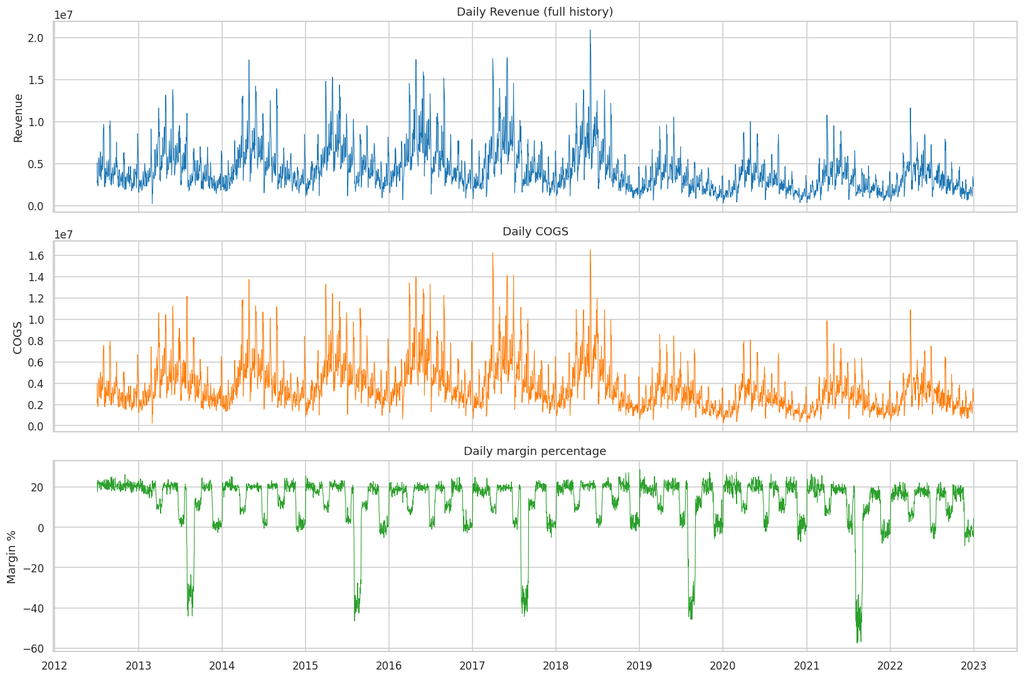

```python
fig, axes = plt.subplots(3, 1, figsize=(15, 10), sharex=True)
axes[0].plot(sales['Date'], sales['Revenue'], color='tab:blue', lw=0.7)
axes[0].set_ylabel('Revenue')
axes[0].set_title('Daily Revenue (full history)')

axes[1].plot(sales['Date'], sales['COGS'], color='tab:orange', lw=0.7)
axes[1].set_ylabel('COGS')
axes[1].set_title('Daily COGS')

axes[2].plot(sales['Date'], sales['margin_pct'] * 100, color='tab:green', lw=0.7)
axes[2].set_ylabel('Margin %')
axes[2].set_title('Daily margin percentage')
axes[2].xaxis.set_major_locator(mdates.YearLocator())
axes[2].xaxis.set_major_formatter(mdates.DateFormatter('%Y'))

plt.tight_layout()
savefig('16_sales_revenue_cogs_margin_history.png')
plt.show()
```

| year | Revenue | COGS | margin | yoy_revenue_growth_% | margin_pct |
| --- | --- | --- | --- | --- | --- |
| 2012 | 741,497,748.02 | 587,461,923.81 | 154,035,824.21 | NaN | 20.77 |
| 2013 | 1,657,169,417.27 | 1,465,980,103.20 | 191,189,314.07 | 123.49 | 11.54 |
| 2014 | 1,871,845,882.80 | 1,574,607,456.89 | 297,238,425.91 | 12.95 | 15.88 |
| 2015 | 1,889,933,826.92 | 1,665,441,817.42 | 224,492,009.50 | 0.97 | 11.88 |
| 2016 | 2,104,640,677.54 | 1,780,559,392.69 | 324,081,284.85 | 11.36 | 15.40 |
| 2017 | 1,911,164,325.28 | 1,694,385,793.54 | 216,778,531.74 | -9.19 | 11.34 |
| 2018 | 1,850,122,456.08 | 1,542,175,766.14 | 307,946,689.94 | -3.19 | 16.64 |
| 2019 | 1,136,801,441.51 | 1,005,202,883.72 | 131,598,557.79 | -38.56 | 11.58 |
| 2020 | 1,054,512,158.79 | 886,085,097.63 | 168,427,061.16 | -7.24 | 15.97 |
| 2021 | 1,043,039,819.63 | 941,130,120.16 | 101,909,699.47 | -1.09 | 9.77 |
| 2022 | 1,169,748,831.69 | 1,020,420,163.97 | 149,328,667.72 | 12.15 | 12.77 |

```
Saved -> images/17_annual_revenue_growth_margin.png
```

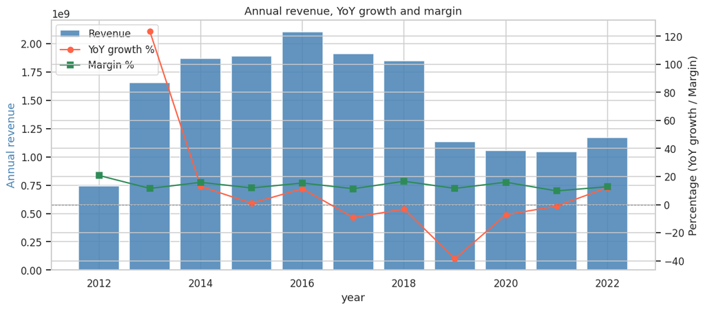

```python
annual = sales.groupby('year').agg(Revenue=('Revenue', 'sum'),
                                    COGS=('COGS', 'sum'),
                                    margin=('margin', 'sum'))
annual['yoy_revenue_growth_%'] = annual['Revenue'].pct_change() * 100
annual['margin_pct']           = annual['margin'] / annual['Revenue'] * 100
display(annual.round(2))

fig, ax1 = plt.subplots(figsize=(12, 5))
ax1.bar(annual.index.astype(int), annual['Revenue'], color='steelblue', alpha=0.85, label='Revenue')
ax1.set_ylabel('Annual revenue', color='steelblue')
ax1.set_xlabel('year')

ax2 = ax1.twinx()
ax2.plot(annual.index.astype(int), annual['yoy_revenue_growth_%'],
         color='tomato', marker='o', label='YoY growth %')
ax2.plot(annual.index.astype(int), annual['margin_pct'],
         color='seagreen', marker='s', label='Margin %')
ax2.set_ylabel('Percentage (YoY growth / Margin)')
ax2.axhline(0, color='grey', lw=0.7, ls='--')

lines1, labels1 = ax1.get_legend_handles_labels()
lines2, labels2 = ax2.get_legend_handles_labels()
ax1.legend(lines1 + lines2, labels1 + labels2, loc='upper left')
plt.title('Annual revenue, YoY growth and margin')
savefig('17_annual_revenue_growth_margin.png')
plt.show()
```